# Session 2

## Session Outline

1. **Explore Data Types**

– Logical, Integer, Double, Character,

Factor

,

Date

1. How to examine data type
2. How to assign data type
2. **Explore Data Structures**

– Vector, List, Matrix, Data Frame

1. How to create each data structure
2. How to modify each data structure
3. How to convert one data structure to another
4. How to explore/examine a given data

## Data Types & Structure

### Why are they important?

Data type & structure…

1. is an attribute associated with a piece of data
2. tells R how to interpret its value
3. ensures that data is collected in the preferred format
- Value of each property is as expected
- Helps to gather clean and consistent data

## 6 Basic Variable Types in R

1. Logical (Boolean):

   e.g.

   TRUE

   ,

   FALSE
2. Integer:

   e.g.

   1L

   (the

   L

   tells R to store it as an integer)
3. Double:

   e.g.

   1.0

   ,

   pi
4. Character (String):  
   e.g.

   “hello”

   ,

   “1”
5. Complex (Real + Imaginary number):

   e.g

   0+1i

   ,

   3+2i
6. Raw (Any data stored as raw bytes):

   e.g. “hello” is

   68

   65

   6c

   6c

   6f

**NOTE**: type `numeric` means `integer` or `double`

## Other Variable Types in R

### Factor

1. Factor variables take on a limited number of different values
- Referred as categorical variable
2. Both numeric and character variables can be made into factors
- Factor’s levels are in character values
- Cannot be used in arithmetic operation
3. Statistical models treat factor and integer variable differently
4. Factors can be ordered (ordinal) or with no order (nominal)

## Other Variable Types in R

### Date

1. Dates are represented as the number of days since 1970-01-01
- Add/subtract days/dates possible
- Negative values mean earlier date then the reference date
2. Character variable can be converted to date variable

## Other Variable Types in R

### Special Values – NA, Inf, NaN

1. `NA` – represents missing data in R
2. `Inf` – represents infinity in R
- Can be either positive or negative
- e.g.

  1/0
3. `NaN` – represents undefined value
- `NaN` means “Not a Number”
- e.g.

  0/0

## How to Examine Data Type & Structure

1. `is.*()`: Returns

   TRUE

   or

   FALSE

   depending on the object type

– [is.logical()](https://www.rdocumentation.org/packages/base/versions/3.6.2/topics/logical), [is.numeric()](https://www.rdocumentation.org/packages/base/versions/3.6.2/topics/numeric), [is.character()](https://www.rdocumentation.org/packages/base/versions/3.6.2/topics/character), [is.factor()](https://www.rdocumentation.org/packages/base/versions/3.6.2/topics/factor), etc.

```r
is.logical(TRUE)
is.logical(1)
```

2. [`is.na(), anyNA()`](https://www.rdocumentation.org/packages/base/versions/3.6.2/topics/NA), [`is.infinite(), is.finite(), is.nan()`](https://www.rdocumentation.org/packages/base/versions/3.6.2/topics/is.finite)

```r
is.na(c(1,2,NA, NaN, Inf))
is.infinite(c(1,2,NA, NaN, Inf))
is.nan(c(1,2,NA, NaN, Inf))
```

3. `as.*()`: Attempts to coerce its argument to be of * type

– as.logical(), as.numeric(),as.character(),as.factor(), etc.

```r
as.character(5)
```

Type is `is.` in R Studio and see the list of suggested functions

## How to Examine Data Type & Structure

Examine the type of data

(**Object** to be more specific)

1. [`typeof()`](https://www.rdocumentation.org/packages/base/versions/3.6.2/topics/typeof): Returns the type of any object

   (data and code)
- A type of an object is mutually exclusive – an object can have only one type
- **NOTE**: Check [`mode()/storage.mode()`](https://www.rdocumentation.org/packages/base/versions/3.6.2/topics/mode)  
  – distinctions among the three often blurred in R
2. [`str()`](https://www.rdocumentation.org/packages/utils/versions/3.6.2/topics/str): A function for displaying the structure of an object
3. [`class()`](https://www.rdocumentation.org/packages/base/versions/3.6.2/topics/class): A function to access an object’s class
- An object’s class determines how generic functions operate with it
- A class of an object is **NOT** mutually exclusive
- If an object has no specific class assigned, it’s class is the same as its `mode`
4. [`attributes()`](https://www.rdocumentation.org/packages/base/versions/3.6.2/topics/attributes): A function to access an object’s attributes

**Note**: Hyperlink to an interesting post on [stackoverflow](https://stackoverflow.com/questions/35445112/what-is-the-difference-between-mode-and-class-in-r)

## 5 Basic Data structure in R

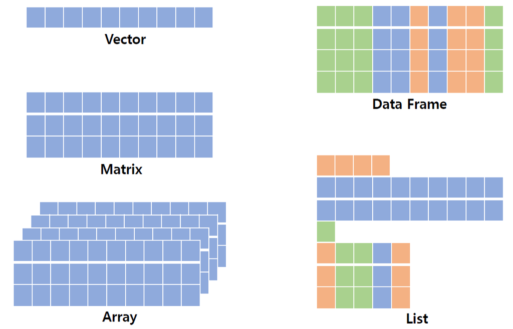

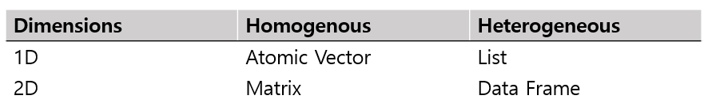

## 5 Basic Data structure in R

1. (Atomic) vector
- 1D & homogeneous – All values in a vector have to be of the same data type
- Workhorse of R
2. List (generic vector)
- 1D & heterogeneous – Elements of a list can be any mixture of data types
3. Matrix/Array
- 2D & homogeneous – All values in a matrix/array have to be of the same type
4. Data Frame
- 2D & heterogeneous – List of vectors of equal length
- Each item in a column have to be of the same type

## Vector

### How to create a vector

1. Creating an empty vector

```r
vector()                       # the default is an empty logical vector
vector("numeric", length=3)    # a numeric vector of length 3
numeric(3)                     # generates the same output as the above
```

check -- logical(), integer(), double(), character()

2. [`c()`](https://www.rdocumentation.org/packages/base/versions/3.6.2/topics/c) – Combine values into a vector / list

```r
c(1,2, 3, 4,5, Inf, NaN)
c("Stuzin", "Hough", "Bryan", "Heavener", NA)
c(T, TRUE, F, FALSE)
# What happens when multiple data types are combined in a single vector?
c(TRUE, FALSE, NA, Inf)
c(1, T, "Stuzin", NA, Inf, NaN)
```

## Vector

### How to create a vector

2. (continue) [`c()`](https://www.rdocumentation.org/packages/base/versions/3.6.2/topics/c) – Combine values into a vector / list

```r
vect1=c(1,2,3)
vect2=c(4,5,6)
c(vect1, vect2)
```

```r
# Named vectors
named_vec <- c(eastern="Florida", central="Iowa",       # Note it is "="
            mountain="Colorado",  pacific="California")
# or
named_vec <- c("Florida", "Iowa", "Colorado",  "California")
names(named_vec) <- c("eastern", "central", "mountain", "pacific")
named_vec
```

```
     eastern      central     mountain      pacific
   "Florida"       "Iowa"   "Colorado" "California"
```

## Vector

### How to create a vector

3. Vector as a sequential numbering
- [`:`](https://www.rdocumentation.org/packages/base/versions/3.6.2/topics/Colon) function

```r
1:5     # from:to
```

- [`seq()`](https://www.google.com/search?client=firefox-b-1-d&q=r+document+seq) function

```r
seq(from=1, to=2, by=0.1)
```

4. [`rep()`](https://www.rdocumentation.org/packages/base/versions/3.6.2/topics/rep) – Replicate elements of a vector / list

```r
rep(1:4, times=2)        # 12341234
rep(1:4, each=2)         # 11223344
rep(1:4, each=2, len=4)  # 1122
rep(1:4, c(2,1,2,1))     # 112334
```

## Vector

### How to create a vector

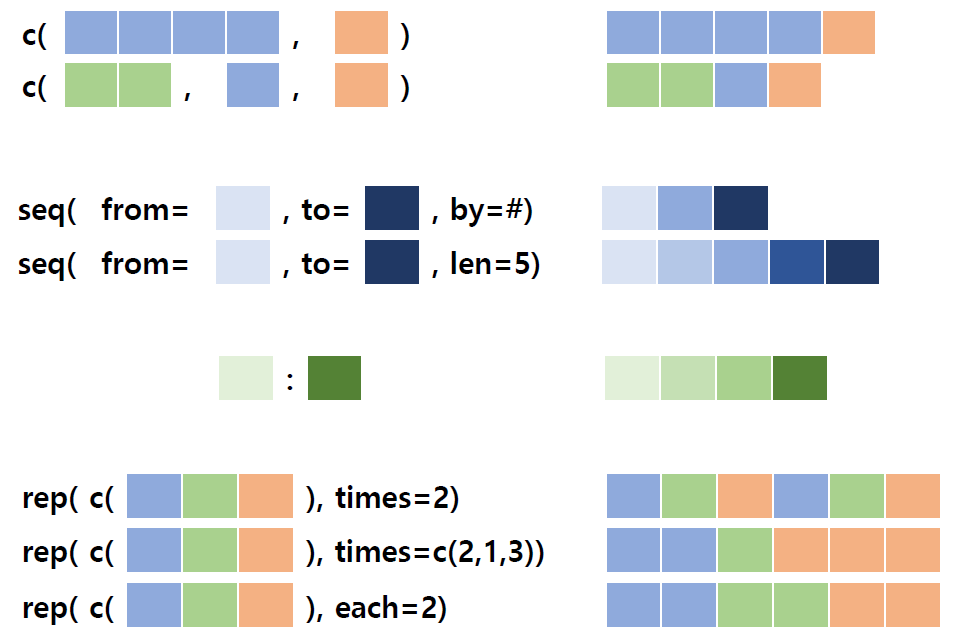

**Note**: Different colors do NOT indicate different data types; It indicates different value of a same data type

## Vector

### Examining vectors

1. Check type

```r
UF_bldg<-c("Stuzin", "Hough", "Bryan", "Heavener")
typeof(UF_bldg)
is.character(UF_bldg)
str(UF_bldg)
is.vector(UF_bldg)
```

2. [`length()`](https://www.rdocumentation.org/packages/base/versions/3.6.2/topics/length) – A function to get/set the length of an object

```r
length(UF_bldg)     # 4
```

3. [`names()`](https://www.rdocumentation.org/packages/base/versions/3.6.2/topics/names) – A function to get/set the names of an object

```r
names(UF_bldg)                                  # NULL -- no name
names(UF_bldg)<-c("STZ", "HGS", "BRY", "HVNR")  # Name with abbreviation
names(UF_bldg)<-NULL                            # Nullify names
```

## Vector

### How to subset a vector

Use square brackets `[]` to subset a vector

```r
# Basic Syntax
a_vector[condition] # The condition is going to be a vector as well
```

Possible condition types

1. Logical vector
2. Index (integer)
3. Names

## Vector

### How to subset a vector

1. Logical vector
- Character Example

```r
# UF_bldg was declared from the previous slide
# UF_bldg<-c("Stuzin", "Hough", "Bryan", "Heavener")
UF_bldg[c(T, F, T, T)]  # subset the values when TRUE
```

```r
UF_bldg == "Hough"                          # Single match
UF_bldg %in% c("Stuzin", "Bryan")           # Multiple matches
UF_bldg[UF_bldg %in% c("Stuzin", "Bryan")]  # Note the use of "%in%"
```

- Numeric Example

```r
x<-1:5
x[x > 2 & x <= 4]  # the output of  "x > 2 & x <= 4" is c(F, F, T, T, F)
!(x > 2 & x <= 4)  # Negate T/F by adding "!" operator  c(T, T, F, F, T)
```

## Vector

### How to subset a vector

2. Index (integer)

```r
UF_bldg[c(1, 3:4)]   # subset the values by indexing
UF_bldg[-c(1, 3:4)]  # `-` indicates "exclude". Result same as "UF_bldg[2]"
UF_bldg[1]           # A single index does not require "c()"
UF_bldg[3:4]         # A sequence can also be used
```

How to convert a logical vector to an index?  
– Use the [`which()`](https://www.rdocumentation.org/packages/base/versions/3.6.2/topics/which) function

```r
x<-1:5
x > 2 & x <= 4           # the output of  "x > 2 & x <= 4" is c(F, F, T, T, F)
which(x > 2 & x <= 4)    # the output is c(3, 4)
x[which(x > 2 & x <= 4)] # equivalent to x[c(3,4)]
```

## Vector

### How to subset a vector

3. Names – Only applicable when a vector is named

```r
# Recall we have named the vector "UF_bldg"
UF_bldg[c("STZ", "HVNR")]
```

```
       STZ       HVNR
  "Stuzin" "Heavener"
```

4. [`subset()`](https://www.rdocumentation.org/packages/base/versions/3.6.2/topics/subset)function

```r
subset(1:5, x > 2 & x <= 4 )  # Recall x<-1:5, output is 3 4
```

**Note**: Other [set operations](https://stat.ethz.ch/R-manual/R-devel/library/base/html/sets.html)